# ACT11302 Examen Final

Juan Carlos Martinez Ovando

7 Mayo 2017

# Datos

Los datos corresponden a los registros de siniestralidad por incendio de un producto de seguros de edificios comerciales en Dinamarca.

Cargamos los datos desde el repositorio del curso empleando las siguientes instrucciones:

```r
load(url("https://github.com/jcmartinezovando/act11302_2017a/raw/master/datos/ACT11302_DanishInsuranceMultivariate_Data.RData"))
ls()
```

```
## [1] "datos"
```

Los datos estan incluidos en el objeto `datos`. El cual contiene los siguientes campos:

- `positions`, correspondiente a la fecha [`mm/dd/aaaa`] de reclamo/siniestro (en este momento, no es relevante la diferencia entre la fecha de ocurrencia del siniestro y la fecha del reclamo)
- `building`, danos al edificio causados por el incendio
- `contents`, danos al contenido del edificio
- `profits`, danos sobre ganancias derevidas de la perdida de operacion
- `total`, perdidas totales

```r
head(datos); tail(datos)
```

```
##    positions building  contents   profits    total
## 1 01/03/1980 1.098097 0.5856515 0.0000000 1.683748
## 2 01/04/1980 1.756955 0.3367496 0.0000000 2.093704
## 3 01/05/1980 1.732581 0.0000000 0.0000000 1.732581
## 4 01/07/1980 0.000000 1.3053760 0.4743777 1.779754
## 5 01/07/1980 1.244510 3.3674960 0.0000000 4.612006
## 6 01/10/1980 4.452040 4.2732340 0.0000000 8.725274
```

```
##       positions  building  contents   profits    total
## 2162 12/24/1990 0.0000000 1.2376240 0.0000000 1.237624
## 2163 12/27/1990 0.7021452 0.4125413 0.0000000 1.114686
## 2164 12/30/1990 0.0000000 0.9900990 0.4125413 1.402640
## 2165 12/30/1990 2.0627063 2.3927390 0.4125413 4.867987
## 2166 12/30/1990 1.0726073 0.0000000 0.0000000 1.072607
## 2167 12/31/1990 3.7128713 0.4125413 0.0000000 4.125413
```

```r
summary(datos[,c("building","contents","profits","total")])
```

```
##     building          contents            profits
##  Min.   :  0.000   Min.   :  0.00000   Min.   : 0.00000
##  1st Qu.:  0.854   1st Qu.:  0.07228   1st Qu.: 0.00000
##  Median :  1.270   Median :  0.37267   Median : 0.00000
##  Mean   :  1.824   Mean   :  1.31854   Mean   : 0.24214
##  3rd Qu.:  1.900   3rd Qu.:  1.11235   3rd Qu.: 0.05901
##  Max.   :152.413   Max.   :132.01320   Max.   :61.93265
##      total
##  Min.   :  1.000
##  1st Qu.:  1.321
##  Median :  1.778
##  Mean   :  3.385
##  3rd Qu.:  2.967
##  Max.   :263.250
```

```r
nrow(datos)
```

```
## [1] 2167
```

Las polizas de seguros para este producto de seguros comprende:

1. Danos a la estructura del eficio
2. Dano al contenidos
3. Perdidas sobre ganancias comerciales

Y el acumulado de los tres danos.

Los datos comprenden el registro de $2,167$ siniestros individuales. Noten que algunos campos son iguales a $0$, lo que equivale a interpretar que los siniestros en la cobertura correspondiente fueron nulos.

Considera que la suscripcion total de polizas durante estos 11 anos de operacion ha sido igual a $108,350$ (tomando la parte proporcional igual por cada ano).

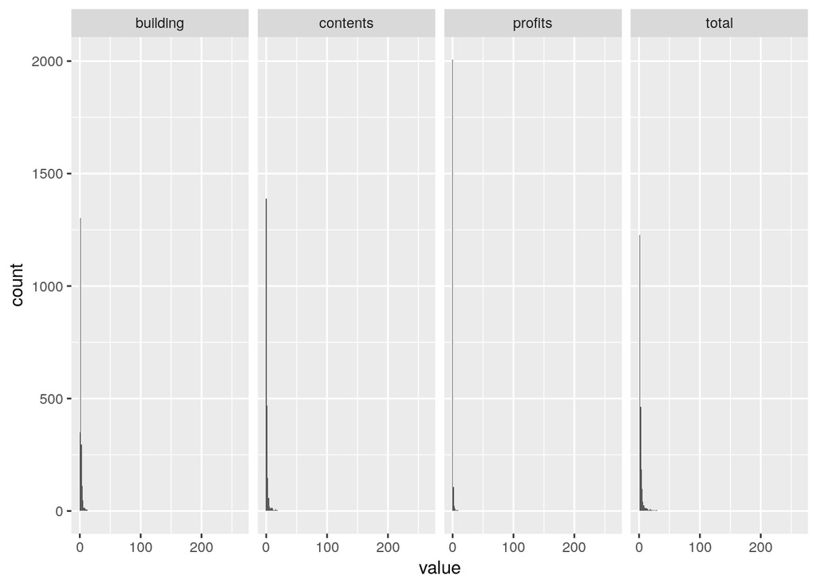

```r
ggplot(gather(datos[,c("building","contents","profits","total")], cols, value),
       aes(x = value)) + geom_histogram(binwidth = 1.3) + facet_grid(.~cols)
```

# Problemas

Refieran al archivo `ACT11302_2017-A_ExamenFinal.pdf` que les comparti via email.

## Referencias

- Meyers y Schenker, “Parameter uncertainty in the collective risk model”, [Link](https://www.casact.org/pubs/proceed/proceed83/83111.pdf) o [Link](https://github.com/jcmartinezovando/act11302_2017a/blob/master/referencias/Meyers_Schenker.pdf)
- Sarabia et al., “Risk aggregation in multivariate dependent Pareto distributions”, [Link](http://www.sciencedirect.com/science/article/pii/S0167668715300457) o [Link](https://github.com/jcmartinezovando/act11302_2017a/blob/master/referencias/Sarabia_etal.pdf)